# Two Sample T-test Power Calculator Pitch deck

2023-03-24

## Motivation

Nowadays different sectors run experiments or A/B tests to test the impact of a new strategy. The pharmaceutical industry may want to test a new medicine, the e-commerce company may want to test a different creative, or an App company may want to test a new product. The examples are many, but the theory behind these tests rely on the Hypothesis test, a field under Statistical inference.

In order to design a test or an experiment, we look for maximizing the chances of detecting an impact if it exists. In other words, we need a well powered test.

Therefore, the Two Sample T-test Power Calculator provides an easy way for users to calculate power for the their experiments.

## What is the Two Sample T-test Power Calculator

The Two Sample T-test Power Calculator is a tool built in Shiny that computes the power for a experiment for two T distributed groups.

It uses the R function `power.t.test` based on the power for a Gossett’s \(T\) test:

\[ P\left(\frac{\bar X - \mu_0}{S /\sqrt{n}} > t_{1-\alpha, n-1} ~|~ \mu = \mu_a \right) \]

## A Simple example of a Two Sample T-test Power Calculator

Below you can find a simple example using the R function `power.t.test` which is the core of the Two Sample T-test Power Calculator.

```r
power.t.test(
  n = 50,
  delta = 2,
  sd = 1,
  sig.level = 0.05,
  type = "two.sample",
  alternative = "two.sided"
)$power
```

```
## [1] 1
```

## The Two Sample T-test Power Calculator on Shiny

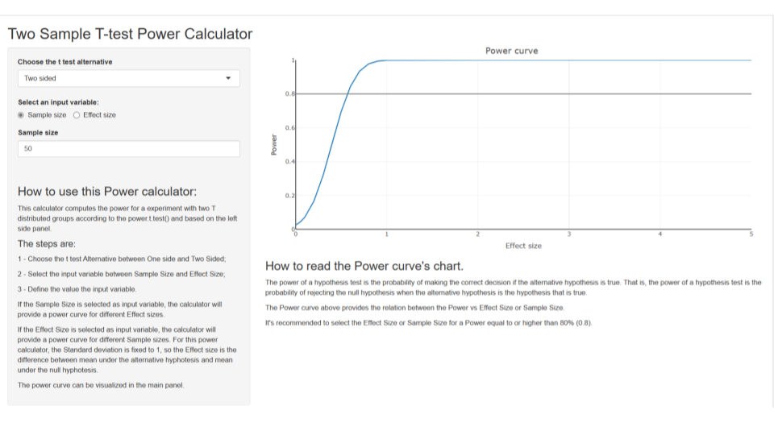

The documentation about how to use the tool can be found in the tool itself.